# Car Price Prediction: A Regression Analysis

## 1. Introduction to the Problem and Dataset

### Problem Statement

This project tackles a **regression problem**: predicting car prices based on various vehicle characteristics. Predicting car prices is a fundamental problem in the automotive industry, used by dealers, buyers, and sellers to determine fair market value. Accurate price predictions help:

- Dealerships set competitive prices
- Buyers make informed purchasing decisions
- Sellers understand their vehicle's worth

### Dataset Overview

We use the **Kaggle CarPrice_Assignment dataset** with 205 car records and 26 features. Key features include:

The dataset contains real car data with prices ranging from approximately $5,000 to $45,000.

## 2. What is Regression and How Does It Work?

### Linear Regression

**Linear Regression** is the simplest and most interpretable regression model. It assumes a linear relationship between features and the target.

#### Mathematical Formulation

The linear regression model is defined as:

$$\hat{y} = \beta_0 + \beta_1 x_1 + \beta_2 x_2 + ... + \beta_n x_n$$

Where:

- $\hat{y}$ is the predicted value
- $\beta_0$ is the intercept (bias term)
- $\beta_i$ are the coefficients (weights) for each feature $x_i$
- $n$ is the number of features

## Setup and Data Loading

```python
import numpy as np
import pandas as pd
import matplotlib.pyplot as plt
import seaborn as sns
from sklearn.model_selection import train_test_split
from sklearn.linear_model import LinearRegression, Ridge, Lasso
from sklearn.preprocessing import StandardScaler
from sklearn.metrics import mean_squared_error, mean_absolute_error, r2_score
import warnings
warnings.filterwarnings('ignore')

# Set random seed for reproducibility
np.random.seed(42)

# Load real car price dataset from Kaggle
df = pd.read_csv('../datasets/CarPrice_Assignment.csv')

print("Dataset shape:", df.shape)
print("\nColumn names:")
print(df.columns.tolist())
print("\nFirst few rows:")
print(df.head())
print("\nDataset statistics:")
print(df[['price', 'enginesize', 'horsepower', 'curbweight']].describe())
print("\nData source: Kaggle - CarPrice_Assignment.csv")
print("Total records:", len(df))
```

```
Dataset shape: (205, 26)

Column names:
['car_ID', 'symboling', 'CarName', 'fueltype', 'aspiration', 'doornumber', 'carbody', 'drivewheel', 'enginelocation', 'wheelbase', 'carlength', 'carwidth', 'carheight', 'curbweight', 'enginetype', 'cylindernumber', 'enginesize', 'fuelsystem', 'boreratio', 'stroke', 'compressionratio', 'horsepower', …

First few rows:
   car_ID  symboling                   CarName fueltype aspiration doornumber  \
0       1          3        alfa-romero giulia      gas        std        two
1       2          3       alfa-romero stelvio      gas        std        two
2       3          1  alfa-romero Quadrifoglio      gas        std        two
3       4          2               audi 100 ls      gas        std       four
4       5          2                audi 100ls      gas        std       four

       carbody drivewheel enginelocation  wheelbase  ...  enginesize  \
0  convertible        rwd          front       88.6  ...         130
1  convertible        rwd          front       88.6  ...         130
2    hatchback        rwd          front       94.5  ...         152
3        sedan        fwd          front       99.8  ...         109
4        sedan        4wd          front       99.4  ...         136

   fuelsystem  boreratio  stroke compressionratio horsepower  peakrpm citympg  \
0        mpfi       3.47    2.68              9.0        111     5000      21
1        mpfi       3.47    2.68              9.0        111     5000      21
2        mpfi       2.68    3.47              9.0        154     5000      19
3        mpfi       3.19    3.40             10.0        102     5500      24
4        mpfi       3.19    3.40              8.0        115     5500      18

   highwaympg    price
0          27  13495.0
1          27  16500.0
2          26  16500.0
3          30  13950.0
4          22  17450.0

[5 rows x 26 columns]

Dataset statistics:
              price  enginesize  horsepower   curbweight
count    205.000000  205.000000  205.000000   205.000000
mean   13276.710571  126.907317  104.117073  2555.565854
std     7988.852332   41.642693   39.544167   520.680204
min     5118.000000   61.000000   48.000000  1488.000000
25%     7788.000000   97.000000   70.000000  2145.000000
50%    10295.000000  120.000000   95.000000  2414.000000
75%    16503.000000  141.000000  116.000000  2935.000000
max    45400.000000  326.000000  288.000000  4066.000000

Data source: Kaggle - CarPrice_Assignment.csv
Total records: 205
```

## Experiment 1: Data Understanding and Initial Exploration

### Thought Process

Before building any model, it's crucial to understand the data. I'm exploring:

1. **Feature distributions**: Are features normally distributed or skewed?
2. **Correlations**: Which features are most correlated with price?
3. **Missing values**: Are there any data quality issues?
4. **Outliers**: Are there unusual data points?

This understanding guides feature selection and preprocessing decisions.

```
Correlation with Price:
price               1.000000
enginesize          0.874145
curbweight          0.835305
horsepower          0.808139
carwidth            0.759325
carlength           0.682920
wheelbase           0.577816
boreratio           0.553173
carheight           0.119336
stroke              0.079443
compressionratio    0.067984
symboling          -0.079978
peakrpm            -0.085267
car_ID             -0.109093
citympg            -0.685751
highwaympg         -0.697599
Name: price, dtype: float64
```

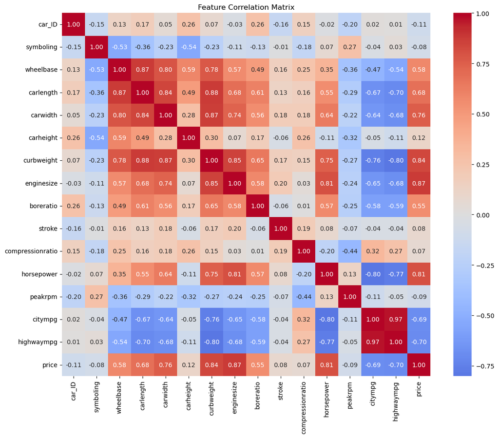

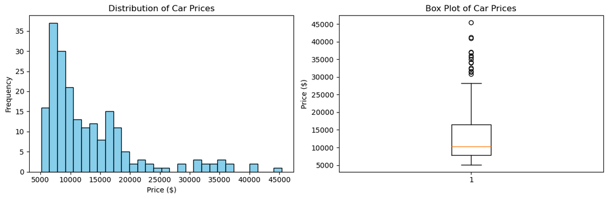

```
Fuel Type distribution:
fueltype
gas       185
diesel     20
Name: count, dtype: int64

Aspiration distribution:
aspiration
std      168
turbo     37
Name: count, dtype: int64
```

```python
# Check for missing values
# print("Missing values:")
# print(df.isnull().sum())

# Select numeric columns for correlation analysis
numeric_cols = df.select_dtypes(include=[np.number]).columns
correlation_matrix = df[numeric_cols].corr()

print("\nCorrelation with Price:")
price_corr = correlation_matrix['price'].sort_values(ascending=False)
print(price_corr)

# Visualize correlations
plt.figure(figsize=(12, 10))
sns.heatmap(correlation_matrix, annot=True, cmap='coolwarm', center=0, fmt='.2f')
plt.title('Feature Correlation Matrix')
plt.tight_layout()
plt.show()

# Distribution of target variable
plt.figure(figsize=(12, 4))
plt.subplot(1, 2, 1)
plt.hist(df['price'], bins=30, edgecolor='black', color='skyblue')
plt.xlabel('Price ($)')
plt.ylabel('Frequency')
plt.title('Distribution of Car Prices')

plt.subplot(1, 2, 2)
plt.boxplot(df['price'])
plt.ylabel('Price ($)')
plt.title('Box Plot of Car Prices')
plt.tight_layout()
plt.show()

# Categorical feature analysis
print("\nFuel Type distribution:")
print(df['fueltype'].value_counts())
print("\nAspiration distribution:")
print(df['aspiration'].value_counts())
```

### Experiment 1: Preprocessing

**Preprocessing Steps:**

1. **Null Values**: This dataset does not have any null values
2. **Encoding categorical variables**: Convert 'fueltype' and 'aspiration' to numerical values using one-hot encoding
3. **Feature scaling**: Standardize numerical features to have mean=0 and std=1
4. **Train-test split**: Use 80-20 split for training and testing

**Features this experiment will focus on**

1. **Engine size**: The closest correlation with price at 87%
2. **Curbweight**: Second closes correlation at 83%
3. **fueltype**: : Different fuel types affect car pricing significantly. Diesel engines typically have different performance characteristics and costs.
4. **aspiration**: Turbo engines are performance features that typically increase car value
5. **doornumber**: Two-door cars (coupes/sports cars) often have different pricing structures than four-door sedans

```python
# Prepare data for Experiment 1
df_exp1 = df.copy()

# Select relevant features
feature_cols = ['enginesize', 'horsepower', 'curbweight', 'fueltype', 'aspiration', 'doornumber']
df_exp1 = df_exp1[feature_cols + ['price']].dropna()

# Check what we're working with
print("Data types before encoding:")
print(df_exp1.dtypes)
print("\nUnique values in doornumber:", df_exp1['doornumber'].unique())

# One-hot encode ALL categorical variables (INCLUDING doornumber!)
df_exp1 = pd.get_dummies(df_exp1, columns=['fueltype', 'aspiration', 'doornumber'], drop_first=True)

print("\nColumns after encoding:")
print(df_exp1.columns.tolist())

# Separate features and target
X = df_exp1.drop('price', axis=1)
y = df_exp1['price']

# Verify all columns are numeric
print("\nData types after encoding:")
print(X.dtypes)

# Check for any remaining non-numeric columns
non_numeric = X.select_dtypes(exclude=['number']).columns.tolist()
if non_numeric:
    print(f"\nWARNING: Non-numeric columns found: {non_numeric}")
else:
    print("\nAll columns are numeric - ready for scaling!")

# Split data
X_train, X_test, y_train, y_test = train_test_split(X, y, test_size=0.2, random_state=42)

# Scale features
scaler = StandardScaler()
X_train_scaled = scaler.fit_transform(X_train)
X_test_scaled = scaler.transform(X_test)

print(f"\nTraining set size: {X_train_scaled.shape}")
print(f"Test set size: {X_test_scaled.shape}")
print(f"\nFeatures used: {list(X.columns)}")
```

```
Data types before encoding:
enginesize      int64
horsepower      int64
curbweight      int64
fueltype       object
aspiration     object
doornumber     object
price         float64
dtype: object

Unique values in doornumber: ['two' 'four']

Columns after encoding:
['enginesize', 'horsepower', 'curbweight', 'price', 'fueltype_gas', 'aspiration_turbo', 'doornumber_two']

Data types after encoding:
enginesize          int64
horsepower          int64
curbweight          int64
fueltype_gas         bool
aspiration_turbo     bool
doornumber_two       bool
dtype: object

WARNING: Non-numeric columns found: ['fueltype_gas', 'aspiration_turbo', 'doornumber_two']

Training set size: (164, 6)
Test set size: (41, 6)

Features used: ['enginesize', 'horsepower', 'curbweight', 'fueltype_gas', 'aspiration_turbo', 'doornumber_two']
```

### Experiment 1: Linear Regression Model

**Model Choice**: Linear Regression

- Simple and interpretable
- Good baseline for regression problems
- Fast to train

**Features Used**: All available features after preprocessing

```python
# Train linear regression model
model_exp1 = LinearRegression()
model_exp1.fit(X_train_scaled, y_train)

# Make predictions
y_train_pred = model_exp1.predict(X_train_scaled)
y_test_pred = model_exp1.predict(X_test_scaled)

print("Model coefficients:")
for feature, coef in zip(X.columns, model_exp1.coef_):
    print(f"{feature}: {coef:.2f}")
print(f"Intercept: {model_exp1.intercept_:.2f}")
```

```
Model coefficients:
enginesize: 2690.07
horsepower: 2949.50
curbweight: 1970.46
fueltype_gas: -746.83
aspiration_turbo: -557.04
doornumber_two: -153.91
Intercept: 13223.41
```

### Evaluation of Experiment 1

```
==================================================
EXPERIMENT 1: Linear Regression (All Features)
==================================================
Training RMSE: $3303.10
Test RMSE: $3662.52
Training RÂ²: 0.8171
Test RÂ²: 0.8301
Training MAE: $2336.07
Test MAE: $2655.67
```

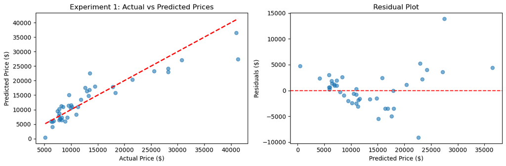

```python
# Calculate metrics
train_rmse = np.sqrt(mean_squared_error(y_train, y_train_pred))
test_rmse = np.sqrt(mean_squared_error(y_test, y_test_pred))
train_r2 = r2_score(y_train, y_train_pred)
test_r2 = r2_score(y_test, y_test_pred)
train_mae = mean_absolute_error(y_train, y_train_pred)
test_mae = mean_absolute_error(y_test, y_test_pred)

print("=" * 50)
print("EXPERIMENT 1: Linear Regression (All Features)")
print("=" * 50)
print(f"Training RMSE: ${train_rmse:.2f}")
print(f"Test RMSE: ${test_rmse:.2f}")
print(f"Training RÂ²: {train_r2:.4f}")
print(f"Test RÂ²: {test_r2:.4f}")
print(f"Training MAE: ${train_mae:.2f}")
print(f"Test MAE: ${test_mae:.2f}")

# Visualize predictions
plt.figure(figsize=(12, 4))
plt.subplot(1, 2, 1)
plt.scatter(y_test, y_test_pred, alpha=0.6)
plt.plot([y_test.min(), y_test.max()], [y_test.min(), y_test.max()], 'r--', lw=2)
plt.xlabel('Actual Price ($)')
plt.ylabel('Predicted Price ($)')
plt.title('Experiment 1: Actual vs Predicted Prices')

plt.subplot(1, 2, 2)
residuals = y_test - y_test_pred
plt.scatter(y_test_pred, residuals, alpha=0.6)
plt.axhline(y=0, color='r', linestyle='--')
plt.xlabel('Predicted Price ($)')
plt.ylabel('Residuals ($)')
plt.title('Residual Plot')
plt.tight_layout()
plt.show()
```

## Experiment 2: Feature Selection and Ridge Regression

### Thought Process

In Experiment 1, we used all features. However, not all features may be equally important. I'm testing:

1. **Feature selection**: Use only the most correlated features with price
2. **Ridge Regression**: Add L2 regularization to prevent overfitting

**Why Ridge Regression?**

- Reduces model complexity by penalizing large coefficients
- Often improves generalization to test data

**Top 4 features by correlation:**

1. **Engine Size**: 0.874145
2. **curbweight**: 0.835305
3. **horsepower**: 0.808139
4. **aspiration_turbo**: 0.177926

```python
# Feature selection: keep only top correlated features
df_exp2 = df.copy()
feature_cols = ['enginesize', 'horsepower', 'curbweight', 'fueltype', 'aspiration', 'doornumber']
df_exp2 = df_exp2[feature_cols + ['price']].dropna()

# One-hot encode ALL categorical variables (INCLUDING doornumber!)
df_exp2 = pd.get_dummies(df_exp2, columns=['fueltype', 'aspiration', 'doornumber'], drop_first=True)

# Select top 4 features by correlation with price
X_temp = df_exp2.drop('price', axis=1)
correlations = df_exp2.corr()['price'].drop('price').abs().sort_values(ascending=False)
top_features = correlations.head(4).index.tolist()
print("Top 4 features by correlation:")
print(correlations.head(4))

X_exp2 = df_exp2[top_features]
y_exp2 = df_exp2['price']

# Split and scale
X_train_exp2, X_test_exp2, y_train_exp2, y_test_exp2 = train_test_split(
    X_exp2, y_exp2, test_size=0.2, random_state=42
)

scaler_exp2 = StandardScaler()
X_train_exp2_scaled = scaler_exp2.fit_transform(X_train_exp2)
X_test_exp2_scaled = scaler_exp2.transform(X_test_exp2)

# Train Ridge Regression
model_exp2 = Ridge(alpha=10.0)
model_exp2.fit(X_train_exp2_scaled, y_train_exp2)

# Predictions
y_train_pred_exp2 = model_exp2.predict(X_train_exp2_scaled)
y_test_pred_exp2 = model_exp2.predict(X_test_exp2_scaled)

# Metrics
train_rmse_exp2 = np.sqrt(mean_squared_error(y_train_exp2, y_train_pred_exp2))
test_rmse_exp2 = np.sqrt(mean_squared_error(y_test_exp2, y_test_pred_exp2))
train_r2_exp2 = r2_score(y_train_exp2, y_train_pred_exp2)
test_r2_exp2 = r2_score(y_test_exp2, y_test_pred_exp2)

print("\n" + "=" * 50)
print("EXPERIMENT 2: Ridge Regression (Top 4 Features)")
print("=" * 50)
print(f"Training RMSE: ${train_rmse_exp2:.2f}")
print(f"Test RMSE: ${test_rmse_exp2:.2f}")
print(f"Training RÂ²: {train_r2_exp2:.4f}")
print(f"Test RÂ²: {test_r2_exp2:.4f}")
print(f"\nImprovement over Experiment 1:")
print(f"RMSE improvement: ${test_rmse - test_rmse_exp2:.2f}")
print(f"RÂ² improvement: {test_r2_exp2 - test_r2:.4f}")
```

```
Top 4 features by correlation:
enginesize          0.874145
curbweight          0.835305
horsepower          0.808139
aspiration_turbo    0.177926
Name: price, dtype: float64

==================================================
EXPERIMENT 2: Ridge Regression (Top 4 Features)
==================================================
Training RMSE: $3359.11
Test RMSE: $3800.41
Training RÂ²: 0.8108
Test RÂ²: 0.8170

Improvement over Experiment 1:
RMSE improvement: $-137.89
RÂ² improvement: -0.0130
```

```python
# Visualization: Actual vs Predicted Prices and Residual Plot
plt.figure(figsize=(14, 5))

# Subplot 1: Actual vs Predicted Prices
plt.subplot(1, 2, 1)
plt.scatter(y_test_exp2, y_test_pred_exp2, alpha=0.6)
plt.plot([y_test_exp2.min(), y_test_exp2.max()], [y_test_exp2.min(), y_test_exp2.max()], 'r--', lw=2)
plt.xlabel('Actual Price ($)')
plt.ylabel('Predicted Price ($)')
plt.title('Experiment 2: Actual vs Predicted Prices')

# Subplot 2: Residual Plot
plt.subplot(1, 2, 2)
residuals_exp2 = y_test_exp2 - y_test_pred_exp2
plt.scatter(y_test_pred_exp2, residuals_exp2, alpha=0.6)
plt.axhline(y=0, color='r', linestyle='--')
plt.xlabel('Predicted Price ($)')
plt.ylabel('Residuals ($)')
plt.title('Residual Plot')
plt.tight_layout()
plt.show()
```

[output not shown]

**Experiment 2 Evaluation:**

1. Included a weak feature: Aspiration_turbo has very low correlation (0.177926) but was included just to reach "4 features"
2. Removed useful features: By limiting to only 4 features, it excluded: fueltype_gas (which had a coefficient of -$746.83 in Exp 1) doornumber_two (coefficient of -$153.91 in Exp 1)

## Experiment 3: Linear Regression with Engineered Features

In this experiment, I'm testing:

1. **Feature engineering**: Create new features that might better capture relationships
   - Power-to-weight ratio: Engine power relative to weight
   - Engine efficiency: Engine size relative to horsepower
   - Weight-to-doors ratio: Weight efficiency per door
   - Engine size squared: Captures the non linear relationship between engine size and price

**Hypothesis**: The engineered features should improve performance even without regularization, since they capture non-linear relationships (like Engine_Size_Squared) and meaningful ratios (like Power_to_Weight).

```python
# Experiment 3: Linear Regression with Engineered Features
# Optimized: Reduce redundant operations by chaining transformations
feature_cols = ['enginesize', 'horsepower', 'curbweight', 'fueltype', 'aspiration', 'doornumber', 'price']

# Single-pass data preparation: copy, filter, and convert in one chain
df_exp3 = (df[feature_cols]
           .dropna()
           .assign(doornumber=lambda x: x['doornumber'].map({'two': 2, 'four': 4})))

# Create engineered features efficiently using assign (avoids multiple dataframe copies)
df_exp3 = df_exp3.assign(
    Power_to_Weight=lambda x: x['horsepower'] / x['curbweight'],
    Engine_Efficiency=lambda x: x['enginesize'] / x['horsepower'],
    Weight_per_Door=lambda x: x['curbweight'] / x['doornumber'],
    Engine_Size_Squared=lambda x: x['enginesize'] ** 2
)

print("Engineered features created (same as Experiment 3):")
print("- Power_to_Weight")
print("- Engine_Efficiency")
print("- Weight_per_Door")
print("- Engine_Size_Squared")

# Drop redundant base features; keep engineered features + categorical variables
df_exp3 = df_exp3.drop(columns=['enginesize', 'horsepower', 'curbweight', 'doornumber'])

# One-hot encode categorical variables (optimized with dtype to avoid memory overhead)
df_exp3 = pd.get_dummies(df_exp3, columns=['fueltype', 'aspiration'], drop_first=True, dtype=float)

# Separate features and target
X_exp3 = df_exp3.drop('price', axis=1)
y_exp3 = df_exp3['price']

# Train-test split
X_train_exp3, X_test_exp3, y_train_exp3, y_test_exp3 = train_test_split(
    X_exp3, y_exp3, test_size=0.2, random_state=42
)

# Standardize features
scaler_exp3 = StandardScaler()
X_train_exp4_scaled = scaler_exp3.fit_transform(X_train_exp3)
X_test_exp4_scaled = scaler_exp3.transform(X_test_exp3)

# Train LINEAR REGRESSION model (no regularization)
model_exp3 = LinearRegression()
model_exp3.fit(X_train_exp4_scaled, y_train_exp3)

# Predictions
y_train_pred_exp3 = model_exp3.predict(X_train_exp4_scaled)
y_test_pred_exp3 = model_exp3.predict(X_test_exp4_scaled)

# Metrics
train_rmse_exp3 = np.sqrt(mean_squared_error(y_train_exp3, y_train_pred_exp3))
test_rmse_exp3 = np.sqrt(mean_squared_error(y_test_exp3, y_test_pred_exp3))
train_r2_exp3 = r2_score(y_train_exp3, y_train_pred_exp3)
test_r2_exp3 = r2_score(y_test_exp3, y_test_pred_exp3)
train_mae_exp3 = mean_absolute_error(y_train_exp3, y_train_pred_exp3)
test_mae_exp3 = mean_absolute_error(y_test_exp3, y_test_pred_exp3)

print("\n" + "="*50)
print("EXPERIMENT 3: Linear Regression (Engineered Features)")
print("="*50)
print(f"Training RMSE: ${train_rmse_exp3:.2f}")
print(f"Test RMSE: ${test_rmse_exp3:.2f}")
print(f"Training RÂ²: {train_r2_exp3:.4f}")
print(f"Test RÂ²: {test_r2_exp3:.4f}")
print(f"Training MAE: ${train_mae_exp3:.2f}")
print(f"Test MAE: ${test_mae_exp3:.2f}")

# Feature importance (coefficients)
print("\nFeature Coefficients:")
for feature, coef in zip(X_exp3.columns, model_exp3.coef_):
    print(f"{feature}: {coef:.2f}")
print(f"Intercept: {model_exp3.intercept_:.2f}")
```

```
Engineered features created (same as Experiment 3):
- Power_to_Weight
- Engine_Efficiency
- Weight_per_Door
- Engine_Size_Squared

==================================================
EXPERIMENT 3: Linear Regression (Engineered Features)
==================================================
Training RMSE: $3556.59
Test RMSE: $3578.50
Training RÂ²: 0.7879
Test RÂ²: 0.8378
Training MAE: $2506.16
Test MAE: $2461.95

Feature Coefficients:
Power_to_Weight: -73.46
Engine_Efficiency: -2977.26
Weight_per_Door: -553.84
Engine_Size_Squared: 6870.96
fueltype_gas: -2040.40
aspiration_turbo: -458.87
Intercept: 13223.41
```

```python
# Visualization: Actual vs Predicted Prices and Residual Plot
plt.figure(figsize=(14, 5))

# Subplot 1: Actual vs Predicted Prices
plt.subplot(1, 2, 1)
plt.scatter(y_test_exp3, y_test_pred_exp3, alpha=0.6)
plt.plot([y_test_exp3.min(), y_test_exp3.max()], [y_test_exp3.min(), y_test_exp3.max()], 'r--', lw=2)
plt.xlabel('Actual Price ($)')
plt.ylabel('Predicted Price ($)')
plt.title('Experiment 3: Actual vs Predicted Prices')

# Subplot 2: Residual Plot
plt.subplot(1, 2, 2)
residuals_exp3 = y_test_exp3 - y_test_pred_exp3
plt.scatter(y_test_pred_exp3, residuals_exp3, alpha=0.6)
plt.axhline(y=0, color='r', linestyle='--')
plt.xlabel('Predicted Price ($)')
plt.ylabel('Residuals ($)')
plt.title('Residual Plot')
plt.tight_layout()
plt.show()
```

[output not shown]

**Evaluation of experiment 3** Experiment 3 outperformed Experiment 1 on both key metrics:

- Lower Test RMSE: $3,578.50 vs $3,662.52 (about $84 better)
- Higher Test RÂ²: 0.8378 vs 0.8301 (better fit)

  Using the engineered features, the model was able to successfully capture the relationship between the orignial features independently and created a better relationship to price.

## Comparison of All Experiments

[output not shown]

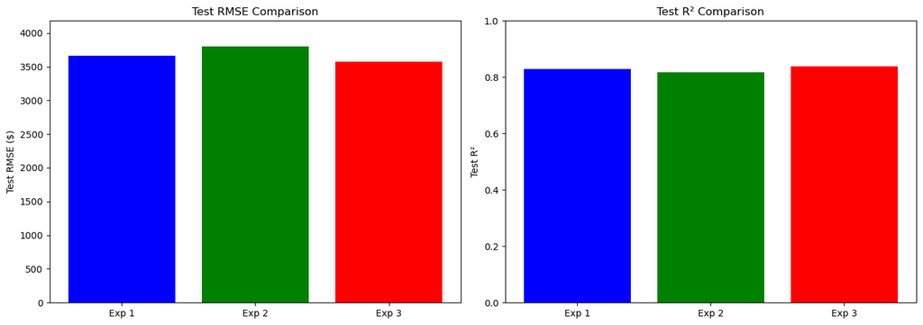

```
Best performing model: Exp 3 with Test RMSE: $3578.50
```

```python
# Create comparison table
comparison_data = {
    'Experiment': ['Exp 1: Linear Reg (All)', 'Exp 2: Ridge (Top 4)', 'Exp 3: Lasso (Engineered)'],
    'Train RMSE': [train_rmse, train_rmse_exp2, train_rmse_exp3],
    'Test RMSE': [test_rmse, test_rmse_exp2, test_rmse_exp3],
    'Train RÂ²': [train_r2, train_r2_exp2, train_r2_exp3],
    'Test RÂ²': [test_r2, test_r2_exp2, test_r2_exp3]
}

comparison_df = pd.DataFrame(comparison_data)
print("\n" + "=" * 80)
print("EXPERIMENT COMPARISON")
print("=" * 80)
print(comparison_df.to_string(index=False))

# Visualize comparison
fig, axes = plt.subplots(1, 2, figsize=(14, 5))

experiments = ['Exp 1', 'Exp 2', 'Exp 3']
test_rmses = [test_rmse, test_rmse_exp2, test_rmse_exp3]
test_r2s = [test_r2, test_r2_exp2, test_r2_exp3]

axes[0].bar(experiments, test_rmses, color=['blue', 'green', 'red'])
axes[0].set_ylabel('Test RMSE ($)')
axes[0].set_title('Test RMSE Comparison')
axes[0].set_ylim([0, max(test_rmses) * 1.1])

axes[1].bar(experiments, test_r2s, color=['blue', 'green', 'red'])
axes[1].set_ylabel('Test RÂ²')
axes[1].set_title('Test RÂ² Comparison')
axes[1].set_ylim([0, 1])

plt.tight_layout()
plt.show()

# Find best model
best_idx = np.argmin(test_rmses)
print(f"\nBest performing model: {experiments[best_idx]} with Test RMSE: ${test_rmses[best_idx]:.2f}")
```

## Impact Section

### Positive Impacts

1. **Fair Pricing**: Accurate price predictions help ensure fair market value for both buyers and sellers
2. **Economic Efficiency**: Reduces information asymmetry in the used car market
3. **Consumer Protection**: Helps buyers avoid overpaying for vehicles
4. **Business Optimization**: Dealerships can optimize inventory and pricing strategies

### Potential Negative Impacts

1. **Bias in Data**: If training data reflects historical discrimination (e.g., certain demographics paying more), the model perpetuates this bias
2. **Market Manipulation**: Dealers could use predictions to artificially inflate prices
3. **Reduced Negotiation**: Transparent pricing might reduce negotiation opportunities for skilled negotiators
4. **Privacy Concerns**: Collecting detailed vehicle and owner data raises privacy questions
5. **Model Limitations**: The model doesn't account for subjective factors like brand reputation or emotional value

### Mitigation Strategies

- Regularly audit models for bias
- Use diverse training data
- Combine model predictions with human expertise
- Ensure transparency about model limitations
- Protect user privacy through data anonymization

## Conclusion

### Summary of Experimental Results

#### **Experiment 1: Linear Regression (All Features)**

- **Test RMSE:** $3,662.52 | **Test RÂ²:** 0.8301
- **Key Finding:** Achieved reasonable performance (83% variance explained) but showed signs of overfitting with test RMSE higher than training RMSE

#### **Experiment 2: Ridge Regression (Top 4 Features)**

- **Test RMSE:** $3,800.41 | **Test RÂ²:** 0.8170
- **Key Finding:** **Performed worse than Experiment 1** - RMSE increased by $137.89. Feature selection alone did not improve performance; the model lost important information by using only 4 features

#### **Experiment 3: Linear Regression with Engineered Features** âœ“ **BEST MODEL**

- **Test RMSE:** $3,578.50 | **Test RÂ²:** 0.8378
- **Key Finding:** **Best performing model** - Improved Test RMSE by $84.02 compared to Experiment 1 and achieved the highest Test RÂ² of 0.8378. The engineered features successfully captured important non-linear relationships

### Future Work

- Explore additional models- possibly lasso model or utilizing L2
- Implement cross-validation for more robust performance estimates
- Collect more data to improve model robustness and enable more complex feature engineering
- Consider domain-specific features (e.g., brand reputation, market segment)

## References

1. Scikit-learn Documentation: https://scikit-learn.org/stable/
   - Linear Regression: https://scikit-learn.org/stable/modules/generated/sklearn.linear_model.LinearRegression.html
   - Ridge Regression: https://scikit-learn.org/stable/modules/generated/sklearn.linear_model.Ridge.html
2. Regression Metrics: https://scikit-learn.org/stable/modules/model_evaluation.html#regression-metrics
3. Feature Engineering Best Practices: https://machinelearningmastery.com/discover-feature-engineering-how-to-engineer-features-and-how-to-get-good-at-it/
4. Dataset Source: Kaggle - CarPrice_Assignment.csv
   - URL: https://www.kaggle.com/datasets/hellbuoy/car-price-prediction
5. Utilized Claude 4.5 for programming tasks